# Technical Report

santa ines

2015

8.250000

2.1794495

16

17

17

47

0

2

68

1

30

1

0

0

11

2

85

0

0

santa ines

2016

9.083333

1.6213537

14

23

13

56

0

3

81

0

28

0

0

1

14

5

89

0

0

santa ines

2017

7.416667

1.7816404

10

14

9

53

0

3

58

0

31

0

0

1

20

10

58

0

0

santa ines

2018

9.583333

3.7284736

19

25

8

58

0

5

81

2

32

2

1

0

17

32

63

0

0

santa lucia

2014

5.111111

2.1473498

4

9

8

24

0

1

31

0

15

0

0

0

4

0

42

0

0

santa lucia

2015

4.666667

1.5569979

5

12

8

30

0

1

37

0

19

0

0

0

7

1

48

0

0

santa lucia

2016

3.583333

1.4433757

1

9

7

21

0

5

31

0

12

0

0

0

5

1

37

0

0

santa lucia

2017

5.250000

1.9128750

9

7

2

42

0

3

41

0

22

0

0

0

20

4

39

0

0

santa lucia

2018

3.916667

1.7816404

1

11

3

32

0

0

23

1

23

1

0

0

13

4

29

0

0

santa margarita

2014

2.444444

2.2973415

4

1

3

10

0

4

16

0

6

0

0

0

3

0

19

0

0

santa margarita

2015

2.083333

1.1645002

2

4

10

9

0

0

16

0

9

0

1

0

1

0

22

0

1

santa margarita

2016

2.636364

1.5015144

5

3

8

10

0

3

22

0

7

0

0

0

4

1

24

0

0

santa margarita

2017

5.090909

2.8444523

10

2

12

30

0

2

44

0

12

0

0

0

4

12

40

0

0

santa margarita

2018

7.000000

2.7633971

14

8

18

41

0

3

63

1

20

1

0

0

10

22

49

0

2

santa maria de los angeles

2014

13.750000

3.0785179

13

4

7

139

0

2

56

0

109

0

1

0

20

8

134

0

2

santa maria de los angeles

2015

14.583333

3.3967453

8

4

6

152

0

5

58

1

116

1

1

0

12

9

150

0

2

santa maria de los angeles

2016

15.416667

3.3427896

24

7

12

138

0

4

76

3

106

3

0

0

8

11

163

0

0

santa maria de los angeles

2017

22.833333

3.5376760

28

3

15

217

0

11

115

0

159

0

2

0

32

32

201

0

7

santa maria de los angeles

2018

14.583333

4.6992907

18

7

9

137

0

4

67

3

105

2

2

0

21

17

132

0

1

santa monica

2014

6.833333

1.3371158

11

4

8

59

0

0

46

1

35

1

0

0

24

1

56

0

0

santa monica

2015

6.583333

2.3915888

15

5

5

51

0

3

54

1

24

1

0

0

24

2

52

0

0

santa monica

2016

8.250000

2.8643578

9

3

17

69

0

1

67

0

32

0

0

0

29

3

67

0

0

santa monica

2017

6.333333

3.0251471

7

4

9

53

0

3

53

0

23

0

0

0

32

11

33

0

0

santa monica

2018

5.333333

1.8257419

6

6

4

47

0

1

39

0

25

0

1

0

27

7

29

0

0

santa rosa de lima

2014

1.400000

0.5477226

1

1

2

2

0

1

5

1

1

1

0

0

2

0

4

0

0

santa rosa de lima

2015

1.333333

0.5773503

0

1

0

3

0

0

3

0

1

0

0

0

2

0

2

0

0

santa rosa de lima

2016

1.000000

NA

0

0

1

0

0

0

1

0

0

0

0

0

0

0

1

0

0

santa rosa de lima

2017

1.333333

0.5163978

1

0

3

4

0

0

5

0

3

0

0

0

0

2

6

0

0

santa rosa de lima

2018

1.000000

0.0000000

2

2

0

2

0

0

5

0

1

0

0

0

0

2

4

0

0

santa teresita

2014

4.583333

1.8319554

4

3

2

45

0

1

32

0

23

0

1

0

15

2

37

0

0

santa teresita

2015

4.583333

1.5050420

4

5

1

43

0

2

29

0

26

0

0

0

16

2

37

0

0

santa teresita

2016

4.666667

2.3484360

2

3

2

45

0

4

29

0

27

0

0

0

25

1

30

0

0

santa teresita

2017

4.750000

1.4847712

8

3

2

43

0

1

32

0

25

0

0

0

23

10

24

0

0

santa teresita

2018

5.181818

2.0404990

4

2

3

48

0

0

27

0

30

0

0

0

22

7

28

0

0

santander

2014

8.166667

2.6571801

15

29

20

32

0

2

80

1

17

1

0

0

7

5

85

0

0

santander

2015

7.583333

3.2601822

9

22

22

33

0

5

75

1

15

1

0

0

4

9

77

0

0

santander

2016

9.333333

4.1633320

21

20

21

47

0

3

84

3

25

3

0

0

13

3

93

0

0

santander

2017

10.833333

4.4890439

23

31

24

50

0

2

105

1

24

1

2

0

27

22

78

0

0

santander

2018

8.666667

3.6762959

12

26

25

40

0

1

85

2

17

2

0

0

16

37

49

0

0

santo domingo savio no. 1

2014

9.666667

2.8069179

14

41

19

32

0

10

89

1

26

1

0

0

5

5

105

0

0

santo domingo savio no. 1

2015

8.333333

3.0550505

14

41

19

23

0

3

83

1

16

1

0

0

6

7

86

0

0

santo domingo savio no. 1

2016

9.166667

2.8867513

19

34

18

33

0

6

87

0

23

0

0

0

3

10

97

0

0

santo domingo savio no. 1

2017

6.666667

3.0550505

10

24

3

38

0

5

51

0

29

0

0

0

7

13

60

0

0

santo domingo savio no. 1

2018

7.750000

3.1370223

22

33

12

23

0

3

78

3

12

3

0

0

7

35

48

0

0

santo domingo savio no. 2

2014

3.250000

1.5447860

2

14

8

15

0

0

34

0

5

0

0

0

1

3

35

0

0

santo domingo savio no. 2

2015

3.272727

1.7372915

2

20

5

8

0

1

28

1

7

1

1

0

0

2

32

0

0

santo domingo savio no. 2

2016

3.416667

2.2746961

5

19

7

10

0

0

35

1

5

1

0

0

0

4

36

0

0

santo domingo savio no. 2

2017

3.200000

1.2292726

7

10

4

11

0

0

21

0

11

0

0

0

3

10

19

0

0

santo domingo savio no. 2

2018

2.250000

0.9653073

1

8

5

12

0

1

18

0

9

0

0

0

2

9

16

0

0

santo domingo savio no.1

2014

1.000000

0.0000000

1

0

1

0

0

0

2

0

0

0

0

0

0

0

2

0

0

santo domingo savio no.1

2015

1.000000

NA

0

1

0

0

0

0

1

0

0

0

0

0

0

0

1

0

0

santo domingo savio no.1

2017

1.000000

0.0000000

0

1

0

1

0

0

1

0

1

0

0

0

0

0

2

0

0

santo domingo savio no.1

2018

1.000000

0.0000000

0

0

1

1

0

0

2

0

0

0

0

0

0

0

2

0

0

sevilla

2014

21.000000

3.9312270

18

31

19

181

0

3

123

3

126

3

0

10

42

4

192

1

0

sevilla

2015

20.333333

5.9288713

29

22

31

157

0

5

138

2

104

2

2

4

35

10

191

0

0

sevilla

2016

19.583333

5.5507302

19

17

18

177

0

4

115

2

118

2

0

13

46

8

165

1

0

sevilla

2017

24.583333

7.0124348

40

23

30

194

0

8

165

1

129

1

0

16

55

40

183

0

0

sevilla

2018

19.666667

5.8981250

15

27

18

171

0

5

127

2

107

1

0

14

60

29

132

0

0

simon bolivar

2014

5.500000

2.2360680

5

7

5

49

0

0

29

0

37

0

0

0

16

0

50

0

0

simon bolivar

2015

8.333333

2.5346089

9

6

6

76

0

3

61

1

38

1

0

0

30

3

66

0

0

simon bolivar

2016

7.416667

2.5746433

1

3

5

77

0

3

47

0

42

0

0

0

31

2

56

0

0

simon bolivar

2017

6.583333

1.9286516

3

7

3

66

0

0

46

0

33

0

0

6

33

2

37

0

1

simon bolivar

2018

6.500000

2.1532217

5

1

5

67

0

0

40

0

38

0

0

4

38

6

30

0

0

sin nombre

2014

1.000000

0.0000000

1

0

0

1

0

0

2

0

0

0

0

0

1

0

1

0

0

sin nombre

2015

2.000000

NA

1

0

0

1

0

0

2

0

0

0

0

0

1

0

1

0

0

sin nombre

2018

1.000000

NA

0

0

0

1

0

0

0

0

1

0

0

0

1

0

0

0

0

suburbano altavista

2014

2.000000

0.8660254

4

2

4

8

0

0

15

0

3

0

0

0

0

2

16

0

0

suburbano altavista

2015

2.875000

1.5526475

3

3

2

14

0

1

17

0

6

0

0

0

1

1

21

0

0

suburbano altavista

2016

1.666667

0.8660254

0

3

2

9

0

1

10

1

4

1

0

0

0

0

14

0

0

suburbano altavista

2017

2.375000

1.7677670

5

3

2

8

0

1

14

0

5

0

0

0

1

2

16

0

0

suburbano altavista

2018

1.500000

0.7559289

3

2

1

6

0

0

9

0

3

0

0

0

0

3

9

0

0

suburbano chacaltaya

2015

1.000000

0.0000000

1

0

0

1

0

0

1

0

1

0

0

0

0

2

0

0

0

suburbano chacaltaya

2016

1.000000

NA

0

0

0

1

0

0

0

0

1

0

0

0

0

0

1

0

0

suburbano chacaltaya

2017

4.000000

NA

0

0

0

4

0

0

1

0

3

0

0

0

0

0

4

0

0

suburbano el llano

2015

1.000000

NA

0

0

0

1

0

0

0

0

1

0

0

0

0

0

1

0

0

suburbano el llano

2017

1.285714

0.4879500

0

0

1

8

0

0

2

0

7

0

0

0

0

1

8

0

0

suburbano el llano

2018

1.375000

0.5175492

1

2

0

6

0

2

5

0

6

0

0

0

1

1

9

0

0

suburbano el plan

2014

14.250000

8.0693021

52

12

44

45

0

18

145

0

26

0

3

0

0

28

140

0

0

suburbano el plan

2015

7.166667

8.4405227

21

10

21

26

0

8

69

0

17

0

0

0

0

32

54

0

0

suburbano el plan

2016

2.750000

1.4222262

3

9

12

5

0

4

32

0

1

0

0

0

0

30

3

0

0

suburbano el plan

2017

3.333333

1.6329932

5

4

3

7

0

1

16

0

4

0

0

0

1

10

9

0

0

suburbano el tesoro

2014

1.500000

0.7071068

0

0

0

3

0

0

1

0

2

0

0

0

0

0

3

0

0

suburbano el tesoro

2015

1.250000

0.5000000

1

0

0

4

0

0

2

0

3

0

0

0

1

0

4

0

0

suburbano el tesoro

2016

1.000000

0.0000000

2

0

0

0

0

0

2

0

0

0

0

0

0

0

2

0

0

suburbano el tesoro

2017

1.000000

0.0000000

0

0

1

2

0

0

2

0

1

0

0

0

0

0

3

0

0

suburbano el tesoro

2018

1.000000

0.0000000

0

0

0

5

0

2

2

0

5

0

0

1

0

2

4

0

0

suburbano la loma

2014

3.636364

1.0269106

2

4

6

26

0

2

23

0

17

0

0

0

1

0

39

0

0

suburbano la loma

2015

4.000000

1.4770979

7

4

7

29

0

1

32

0

16

0

0

0

1

1

46

0

0

suburbano la loma

2016

4.500000

2.4308622

13

4

9

26

0

2

34

1

19

1

0

0

2

5

45

0

1

suburbano la loma

2017

2.833333

1.6966991

4

9

3

18

0

0

22

1

11

1

0

0

5

3

24

0

1

suburbano la loma

2018

4.833333

2.2495791

14

6

4

31

0

3

38

0

20

0

0

0

3

13

42

0

0

suburbano mirador del poblado

2014

1.400000

0.5477226

0

0

1

5

0

1

3

0

4

0

0

0

0

0

7

0

0

suburbano mirador del poblado

2015

1.500000

0.7559289

1

0

2

7

0

2

7

0

5

0

0

0

0

0

12

0

0

suburbano mirador del poblado

2016

1.200000

0.4472136

0

0

0

5

0

1

4

0

2

0

0

0

0

0

6

0

0

suburbano mirador del poblado

2017

2.142857

1.4638501

3

0

1

10

0

1

8

0

7

0

0

0

4

2

9

0

0

suburbano mirador del poblado

2018

1.818182

1.0787198

2

0

3

13

1

1

9

0

11

0

0

2

0

1

17

0

0

suburbano palma patio

2014

1.333333

0.5773503

0

0

1

3

0

0

3

0

1

0

0

0

1

0

3

0

0

suburbano palma patio

2015

1.333333

0.5773503

0

0

2

2

0

0

4

0

0

0

0

0

0

1

3

0

0

suburbano palma patio

2016

1.666667

0.5773503

2

0

2

1

0

0

4

0

1

0

0

0

0

1

4

0

0

suburbano palma patio

2017

2.000000

1.0000000

0

1

1

4

0

0

2

0

4

0

0

0

2

0

2

0

2

suburbano palma patio

2018

1.666667

0.5773503

0

0

0

5

0

0

2

1

2

1

0

0

0

0

4

0

0

suburbano palmitas

2015

1.000000

0.0000000

1

0

0

1

0

0

1

0

1

0

0

0

0

1

1

0

0

suburbano palmitas

2016

1.333333

0.5773503

0

0

0

4

0

0

1

0

3

0

0

0

0

0

4

0

0

suburbano palmitas

2017

1.000000

0.0000000

0

0

0

2

0

1

1

0

2

0

0

0

0

1

2

0

0

suburbano palmitas

2018

1.000000

NA

0

1

0

0

0

0

0

1

0

1

0

0

0

0

0

0

0

suburbano pedregal alto

2014

1.250000

0.5000000

2

0

0

2

0

1

4

0

1

0

0

0

0

0

5

0

0

suburbano pedregal alto

2015

1.000000

0.0000000

1

0

1

2

0

0

4

0

0

0

0

0

0

0

4

0

0

suburbano pedregal alto

2016

1.222222

0.4409586

5

1

3

1

0

1

11

0

0

0

0

0

0

2

9

0

0

suburbano pedregal alto

2017

1.000000

NA

1

0

0

0

0

0

1

0

0

0

0

0

0

0

1

0

0

suburbano pedregal alto

2018

1.000000

0.0000000

1

0

0

0

0

1

2

0

0

0

0

0

0

0

2

0

0

suburbano potrerito

2017

1.000000

NA

0

1

0

0

0

0

1

0

0

0

0

0

0

0

1

0

0

suburbano travesias

2014

1.500000

0.5270463

4

5

1

5

0

0

12

0

3

0

0

0

1

3

11

0

0

suburbano travesias

2015

1.500000

0.8366600

3

0

2

3

0

1

7

0

2

0

0

0

0

3

6

0

0

suburbano travesias

2016

2.100000

1.1005049

1

5

4

10

0

1

17

0

4

0

0

0

4

1

16

0

0

suburbano travesias

2017

1.625000

0.7440238

4

2

1

4

0

2

11

0

2

0

0

0

1

3

8

0

1

suburbano travesias

2018

2.333333

1.1180340

2

6

4

8

0

1

15

0

6

0

0

0

2

4

14

0

1

sucre

2014

12.083333

4.1000739

15

23

10

91

0

6

92

1

52

1

0

0

30

2

111

0

1

sucre

2015

12.333333

3.6013465

15

19

8

101

0

5

96

1

51

1

0

0

31

2

114

0

0

sucre

2016

12.250000

4.1148291

20

12

9

98

0

8

99

0

48

0

1

0

28

5

111

0

2

sucre

2017

9.916667

2.6097138

14

10

9

81

0

5

81

0

38

0

1

1

48

15

53

0

1

sucre

2018

10.000000

2.6285150

15

7

12

81

0

5

88

2

30

2

0

1

42

26

49

0

0

suramericana

2014

27.583333

5.4013186

21

16

15

276

0

3

128

2

201

2

0

0

68

4

255

0

2

suramericana

2015

29.916667

5.4181233

22

10

16

307

0

4

127

1

231

1

2

0

55

8

293

0

0

suramericana

2016

25.083333

6.2152062

36

16

19

225

0

5

134

3

164

3

0

0

39

10

247

0

2

suramericana

2017

29.583333

5.4515775

27

16

26

273

0

13

163

0

192

0

1

0

92

22

240

0

0

suramericana

2018

26.000000

5.4104276

29

21

13

243

1

5

145

2

165

1

2

0

79

33

195

0

2

tejelo

2014

11.000000

4.8429893

27

19

20

63

0

3

94

4

34

4

1

0

23

3

101

0

0

tejelo

2015

10.333333

2.9644357

21

15

21

62

0

5

92

1

31

1

1

0

29

5

88

0

0

tejelo

2016

14.500000

3.3709993

28

31

30

77

0

8

132

0

42

0

0

0

32

10

132

0

0

tejelo

2017

11.333333

3.4728383

20

19

20

69

0

8

109

0

27

0

0

0

36

17

83

0

0

tejelo

2018

13.083333

3.5791907

11

26

39

76

0

5

117

0

40

0

0

0

39

37

81

0

0

tenche

2014

15.000000

3.3574882

9

10

14

142

0

5

88

0

92

0

2

0

31

1

146

0

0

tenche

2015

18.916667

5.0173940

15

8

7

191

0

6

105

3

119

3

0

0

36

4

184

0

0

tenche

2016

20.083333

5.5178773

23

18

11

185

0

4

136

0

105

0

0

0

51

6

181

0

3

tenche

2017

14.666667

3.5248039

10

4

8

149

0

5

80

0

96

0

2

0

56

10

108

0

0

tenche

2018

14.916667

4.3788403

16

2

6

155

0

0

80

3

96

2

1

0

51

16

106

0

3

terminal de transporte

2014

54.833333

8.2443737

85

47

52

465

0

9

298

3

357

3

1

48

25

24

541

0

16

terminal de transporte

2015

47.666667

5.3143602

64

24

49

418

0

17

250

5

317

5

0

50

24

17

467

0

9

terminal de transporte

2016

45.166667

8.2553931

70

25

26

411

0

10

231

3

308

3

2

66

35

19

406

0

11

terminal de transporte

2017

52.583333

10.0313901

87

36

49

431

0

28

318

5

308

5

5

105

36

71

391

0

18

terminal de transporte

2018

41.916667

7.2420280

40

28

37

382

0

16

235

3

265

3

1

79

35

84

279

0

22

toscana

2014

9.583333

2.1514618

16

7

10

78

0

4

67

2

46

2

0

0

7

3

103

0

0

toscana

2015

10.750000

4.6539328

14

10

15

85

0

5

81

3

45

3

0

0

6

2

115

0

3

toscana

2016

11.083333

3.5791907

15

9

14

92

0

3

85

2

46

2

1

0

6

1

119

0

4

toscana

2017

17.000000

4.1341153

23

13

14

148

0

6

111

0

93

0

0

0

13

14

170

0

7

toscana

2018

19.416667

4.7569726

17

14

14

177

0

11

129

4

100

3

0

0

14

16

192

0

8

travesias

2017

1.000000

NA

0

0

0

1

0

0

0

0

1

0

0

0

0

0

1

0

0

trece de noviembre

2014

1.500000

0.5477226

0

1

2

6

0

0

4

0

5

0

0

0

0

0

9

0

0

trece de noviembre

2015

1.200000

0.4472136

0

4

0

2

0

0

4

0

2

0

0

0

0

0

6

0

0

trece de noviembre

2016

1.555556

1.0137938

0

2

0

12

0

0

4

0

10

0

0

0

0

0

14

0

0

trece de noviembre

2017

1.875000

1.1259916

1

3

0

11

0

0

5

0

10

0

0

0

1

1

13

0

0

trece de noviembre

2018

1.500000

0.7559289

1

4

0

7

0

0

7

0

5

0

1

0

0

0

11

0

0

tricentenario

2014

15.000000

4.5527215

21

10

18

127

0

4

96

0

84

0

0

0

5

5

170

0

0

tricentenario

2015

14.833333

4.7065396

12

8

16

137

0

5

103

2

73

2

0

0

12

2

162

0

0

tricentenario

2016

15.833333

3.9041547

20

11

17

137

0

5

102

1

87

1

0

0

10

4

174

0

1

tricentenario

2017

18.166667

4.4890439

20

11

13

153

0

21

117

1

100

1

1

0

11

19

183

0

3

tricentenario

2018

17.166667

5.0060569

27

8

26

141

0

4

130

1

75

1

0

0

10

27

165

0

3

trinidad

2014

18.833333

3.0401356

27

32

10

152

0

5

139

1

86

1

2

0

55

6

162

0

0

trinidad

2015

19.083333

2.9063671

12

40

13

157

0

7

138

1

90

1

1

0

49

3

175

0

0

trinidad

2016

19.500000

3.5290998

16

27

18

168

0

5

134

3

97

3

0

0

44

5

182

0

0

trinidad

2017

16.583333

3.5280263

22

18

17

133

0

9

119

1

79

1

1

0

53

25

119

0

0

trinidad

2018

15.500000

3.4245106

16

23

4

141

0

2

90

0

96

0

0

0

59

15

112

0

0

u.d. atanasio girardot

2014

5.750000

2.5271256

4

6

5

54

0

0

38

0

31

0

1

0

11

0

57

0

0

u.d. atanasio girardot

2015

5.000000

2.0000000

7

10

4

39

0

0

36

0

24

0

1

0

5

2

52

0

0

u.d. atanasio girardot

2016

5.916667

3.3698755

11

8

5

46

0

1

42

0

29

0

1

0

9

3

58

0

0

u.d. atanasio girardot

2017

4.416667

2.4664414

7

3

1

40

0

2

21

0

32

0

0

1

14

5

32

0

1

u.d. atanasio girardot

2018

4.083333

2.2343733

5

6

6

31

0

1

24

0

25

0

2

0

8

9

30

0

0

u.p.b.

2014

2.333333

1.3662601

4

0

1

9

0

0

8

0

6

0

0

0

0

5

9

0

0

u.p.b.

2015

2.750000

2.1876275

2

1

1

17

0

1

7

0

15

0

0

0

2

3

17

0

0

u.p.b.

2016

2.000000

1.1547005

3

3

0

14

0

0

9

0

11

0

0

0

3

0

17

0

0

u.p.b.

2017

3.666667

1.9694639

2

1

0

38

0

3

11

0

33

0

0

3

12

2

26

0

1

u.p.b.

2018

2.800000

1.3165612

3

1

5

19

0

0

12

1

15

0

0

1

2

3

22

0

0

universidad de antioquia

2014

13.083333

4.1000739

12

16

11

113

0

5

71

0

86

0

3

1

4

1

142

0

6

universidad de antioquia

2015

12.083333

3.5021638

13

10

4

111

0

7

58

1

86

1

0

0

11

4

125

0

4

universidad de antioquia

2016

11.833333

3.7859389

20

4

12

101

0

5

76

0

66

0

0

0

8

3

128

0

3

universidad de antioquia

2017

20.166667

13.9273004

46

7

31

138

0

20

163

1

78

1

2

0

15

24

198

0

2

universidad de antioquia

2018

16.833333

6.2498485

26

10

22

136

0

8

119

2

81

1

0

1

22

22

148

0

8

universidad nacional

2014

34.083333

6.0371326

39

28

25

305

0

12

186

2

221

2

3

0

29

10

354

0

11

universidad nacional

2015

34.583333

4.8702872

38

20

27

312

0

18

215

4

196

4

1

0

41

5

360

0

4

universidad nacional

2016

34.500000

5.7603661

48

14

28

303

0

21

213

2

199

2

0

0

30

11

362

0

9

universidad nacional

2017

28.083333

4.5618643

28

13

24

264

0

8

189

1

147

1

3

1

31

20

253

0

28

universidad nacional

2018

22.500000

3.4245106

22

15

19

201

0

13

138

3

129

3

0

0

25

27

197

0

18

veinte de julio

2014

7.500000

2.7797972

10

19

11

50

0

0

70

2

18

2

1

0

13

1

73

0

0

veinte de julio

2015

6.000000

2.5584086

14

18

5

33

0

2

52

2

18

2

0

0

6

4

60

0

0

veinte de julio

2016

6.000000

2.4120908

8

14

6

38

0

6

55

0

17

0

0

0

14

1

57

0

0

veinte de julio

2017

5.333333

2.7743413

6

17

10

30

0

1

54

2

8

2

0

0

12

7

43

0

0

veinte de julio

2018

5.083333

1.8319554

10

10

5

36

0

0

42

0

19

0

0

0

12

12

37

0

0

versalles no. 1

2014

9.000000

2.6967994

13

32

17

43

0

3

82

1

25

1

0

0

15

5

87

0

0

versalles no. 1

2015

9.583333

3.5021638

21

26

18

44

0

6

83

0

32

0

0

0

12

2

101

0

0

versalles no. 1

2016

8.500000

2.3159526

11

19

10

58

0

4

63

0

39

0

0

0

13

4

85

0

0

versalles no. 1

2017

8.250000

2.5980762

20

27

10

41

0

1

66

1

32

1

2

0

18

14

64

0

0

versalles no. 1

2018

6.416667

1.7298625

13

22

11

27

0

4

56

1

20

1

0

0

7

21

48

0

0

versalles no. 2

2014

1.571429

0.5345225

1

4

1

5

0

0

6

0

5

0

1

0

0

0

10

0

0

versalles no. 2

2015

1.428571

0.5345225

0

3

2

5

0

0

6

0

4

0

0

0

1

0

9

0

0

versalles no. 2

2016

1.142857

0.3779645

1

3

0

4

0

0

4

0

4

0

0

0

0

1

7

0

0

versalles no. 2

2017

1.555556

0.8819171

1

3

3

5

0

2

9

0

5

0

0

0

1

3

10

0

0

versalles no. 2

2018

1.571429

0.5345225

2

3

0

6

0

0

8

0

3

0

0

0

0

3

8

0

0

versalles no.1

2014

1.000000

0.0000000

0

1

0

2

0

0

2

0

1

0

0

0

0

1

2

0

0

versalles no.1

2015

1.000000

NA

0

0

0

1

0

0

0

0

1

0

0

0

0

0

1

0

0

versalles no.1

2016

1.000000

NA

0

0

0

1

0

0

0

0

1

0

0

0

0

0

1

0

0

versalles no.1

2017

1.000000

0.0000000

0

1

0

3

0

0

1

0

3

0

0

0

0

1

3

0

0

versalles no.1

2018

1.000000

0.0000000

0

0

0

1

0

1

1

0

1

0

0

0

0

0

2

0

0

versalles no.2

2015

1.000000

NA

0

0

0

1

0

0

0

0

1

0

0

0

0

0

1

0

0

versalles no.2

2016

1.000000

NA

0

0

0

1

0

0

0

0

1

0

0

0

0

0

1

0

0

versalles no.2

2017

1.000000

NA

0

1

0

0

0

0

1

0

0

0

0

0

0

0

1

0

0

villa carlota

2014

34.250000

5.2936497

20

19

26

340

0

6

183

3

225

3

1

0

39

12

352

1

3

villa carlota

2015

34.500000

5.8542914

22

14

18

349

0

11

172

3

239

3

2

0

38

12

359

0

0

villa carlota

2016

39.583333

9.0900378

25

18

14

403

0

15

208

1

266

1

0

0

49

22

396

0

7

villa carlota

2017

36.500000

8.2406972

21

8

17

376

2

14

152

1

285

1

0

0

63

35

336

0

3

villa carlota

2018

40.916667

7.5010100

24

17

16

424

0

10

170

2

319

2

1

1

64

50

371

0

2

villa del socorro

2014

7.250000

2.0943647

10

24

16

36

0

1

55

3

29

3

1

0

4

0

79

0

0

villa del socorro

2015

6.583333

2.1933094

11

17

9

39

0

3

59

0

20

0

0

0

5

2

72

0

0

villa del socorro

2016

8.416667

2.8431204

17

18

8

54

0

4

67

0

34

0

1

0

8

3

89

0

0

villa del socorro

2017

6.416667

1.9752253

10

16

10

40

0

1

50

0

27

0

0

0

5

11

61

0

0

villa del socorro

2018

7.083333

1.8809250

11

17

4

51

0

2

51

0

34

0

0

0

9

21

55

0

0

villa flora

2014

13.000000

6.3389130

20

8

19

108

0

1

85

0

71

0

0

0

19

3

134

0

0

villa flora

2015

14.916667

3.1176429

22

11

21

117

0

8

109

0

70

0

1

0

18

2

158

0

0

villa flora

2016

12.750000

2.7675063

29

11

20

87

0

6

105

0

48

0

0

0

24

5

124

0

0

villa flora

2017

13.000000

1.9069252

28

5

24

93

0

6

107

0

49

0

1

0

27

22

106

0

0

villa flora

2018

14.666667

4.5193188

36

10

29

96

0

5

113

0

63

0

0

0

28

57

91

0

0

villa guadalupe

2014

6.500000

3.2891005

11

22

8

33

0

4

60

0

18

0

0

0

6

3

69

0

0

villa guadalupe

2015

5.750000

2.3788844

10

15

9

34

0

1

42

2

25

2

1

0

3

1

61

0

1

villa guadalupe

2016

5.000000

2.6285150

8

17

7

27

0

1

46

0

14

0

0

0

5

1

54

0

0

villa guadalupe

2017

6.166667

2.2087978

16

18

11

25

0

4

59

0

15

0

1

0

11

14

47

0

1

villa guadalupe

2018

6.750000

1.9128750

8

22

12

35

0

4

63

0

18

0

0

0

17

16

48

0

0

villa hermosa

2014

10.333333

3.5760144

22

22

19

57

0

4

97

1

26

1

0

0

28

4

91

0

0

villa hermosa

2015

9.416667

3.2039275

18

24

11

53

0

7

89

0

24

0

0

0

29

3

81

0

0

villa hermosa

2016

9.000000

3.3844564

16

13

10

64

0

5

76

0

32

0

0

0

20

5

83

0

0

villa hermosa

2017

8.166667

2.7906771

10

20

10

53

0

5

63

1

34

1

0

0

26

11

60

0

0

villa hermosa

2018

9.416667

4.5016832

15

19

17

55

0

7

81

0

32

0

0

1

30

26

56

0

0

villa liliam

2014

1.818182

1.2504545

5

6

3

5

0

1

18

0

2

0

0

0

2

1

17

0

0

villa liliam

2015

2.181818

1.1677484

2

9

4

8

0

1

18

0

6

0

1

0

0

1

22

0

0

villa liliam

2016

1.833333

0.8348471

3

6

4

9

0

0

19

0

3

0

1

0

1

3

17

0

0

villa liliam

2017

2.222222

1.2018504

4

6

2

8

0

0

15

0

5

0

0

0

4

5

11

0

0

villa liliam

2018

2.250000

1.4222262

1

10

4

9

0

3

23

0

4

0

0

0

1

11

15

0

0

villa lilliam

2014

1.000000

0.0000000

0

1

1

0

0

0

2

0

0

0

0

0

0

1

1

0

0

villa lilliam

2015

1.000000

0.0000000

1

1

0

0

0

0

2

0

0

0

0

0

0

0

2

0

0

villa lilliam

2016

1.000000

NA

0

0

0

1

0

0

0

0

1

0

0

0

0

0

1

0

0

villa lilliam

2017

1.000000

NA

1

0

0

0

0

0

1

0

0

0

0

0

0

1

0

0

0

villa lilliam

2018

1.000000

NA

0

0

1

0

0

0

1

0

0

0

0

0

0

1

0

0

0

villa niza

2014

3.800000

1.6193277

8

9

2

17

0

2

24

0

14

0

0

0

4

3

31

0

0

villa niza

2015

2.916667

1.5050420

6

10

3

14

0

2

20

1

14

1

0

0

4

0

30

0

0

villa niza

2016

2.181818

1.3280197

5

3

5

11

0

0

20

1

3

1

0

0

1

3

19

0

0

villa niza

2017

3.250000

1.7645499

3

7

7

21

0

1

28

0

11

0

0

0

3

3

33

0

0

villa niza

2018

3.454546

1.6949122

2

7

6

22

0

1

26

0

12

0

0

0

3

6

29

0

0

villa nueva

2014

50.166667

8.7472940

41

102

45

404

0

10

286

8

308

8

3

0

108

5

476

1

1

villa nueva

2015

53.166667

12.6694574

49

74

40

458

0

17

291

3

344

3

1

1

123

13

495

0

2

villa nueva

2016

46.000000

8.3883035

44

75

41

371

0

21

273

5

274

5

0

1

96

11

435

0

4

villa nueva

2017

47.333333

8.7835935

36

69

34

410

1

18

275

2

291

2

6

0

166

40

341

0

13

villa nueva

2018

45.666667

8.6269486

41

80

38

379

0

10

262

1

285

1

3

1

160

55

320

0

8

villa turbay

2014

1.250000

0.4629100

4

2

2

2

0

0

9

0

1

0

0

0

1

1

8

0

0

villa turbay

2015

1.428571

0.5345225

1

2

2

5

0

0

8

0

2

0

0

0

0

0

10

0

0

villa turbay

2016

1.571429

0.5345225

1

4

4

2

0

0

9

0

2

0

0

0

1

1

9

0

0

villa turbay

2017

1.333333

0.5773503

0

0

2

2

0

0

4

0

0

0

0

0

0

0

4

0

0

villa turbay

2018

1.600000

1.3416408

3

0

1

4

0

0

5

0

3

0

0

0

0

1

7

0

0

villatina

2014

7.416667

2.8109634

12

20

17

34

1

5

65

0

24

0

0

1

3

3

82

0

0

villatina

2015

7.916667

3.1176429

18

21

19

30

0

7

76

0

19

0

0

0

5

2

88

0

0

villatina

2016

8.583333

2.1933094

13

18

14

53

0

5

69

1

33

1

1

0

5

4

92

0

0

villatina

2017

7.000000

2.2156468

11

18

19

31

0

5

65

1

18

1

0

0

8

24

51

0

0

villatina

2018

8.333333

3.2003788

11

18

18

51

0

2

65

0

35

0

0

0

8

24

68

0

0

volcana guayabal

2018

1.000000

NA

1

0

0

0

0

0

1

0

0

0

0

0

1

0

0

0

0

yolombo

2014

1.000000

NA

0

0

1

0

0

0

1

0

0

0

0

0

0

0

1

0

0

yolombo

2016

1.000000

NA

1

0

0

0

0

0

1

0

0

0

0

0

0

0

1

0

0

yolombo

2017

1.000000

0.0000000

1

0

0

1

0

0

2

0

0

0

0

0

0

1

1

0

0

yolombo

2018

1.625000

0.9161254

1

1

0

10

0

1

5

0

8

0

0

0

0

1

12

0

0

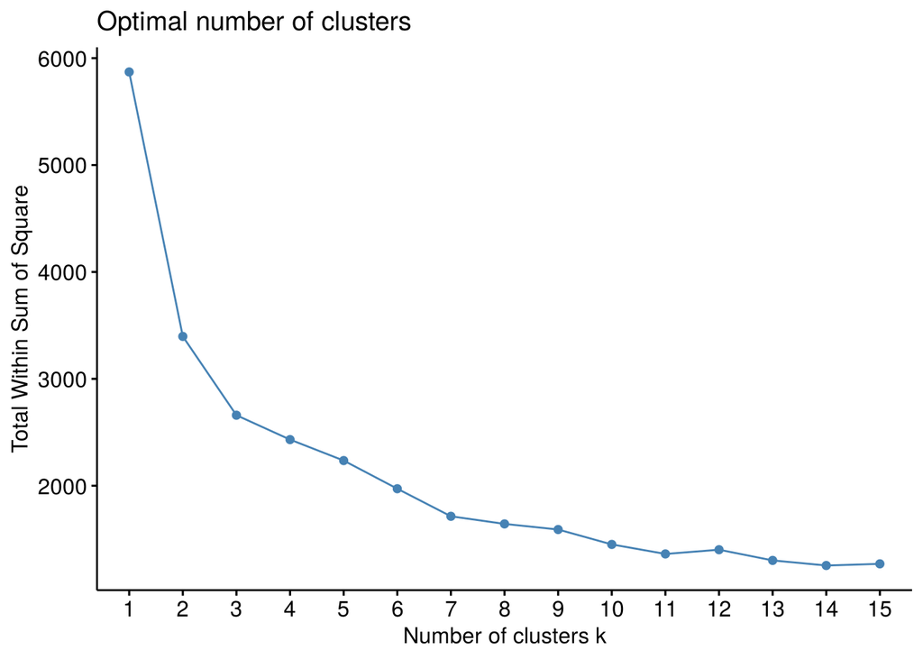

No obstante, es importante resaltar que para el año 2017 no se cumplio completamente el patron de los 4 cluster (solo se evidenciaban 3 cluster) que se encontraban para los otros años; por esta razón se optó por dejarlo con un `k = 3`.

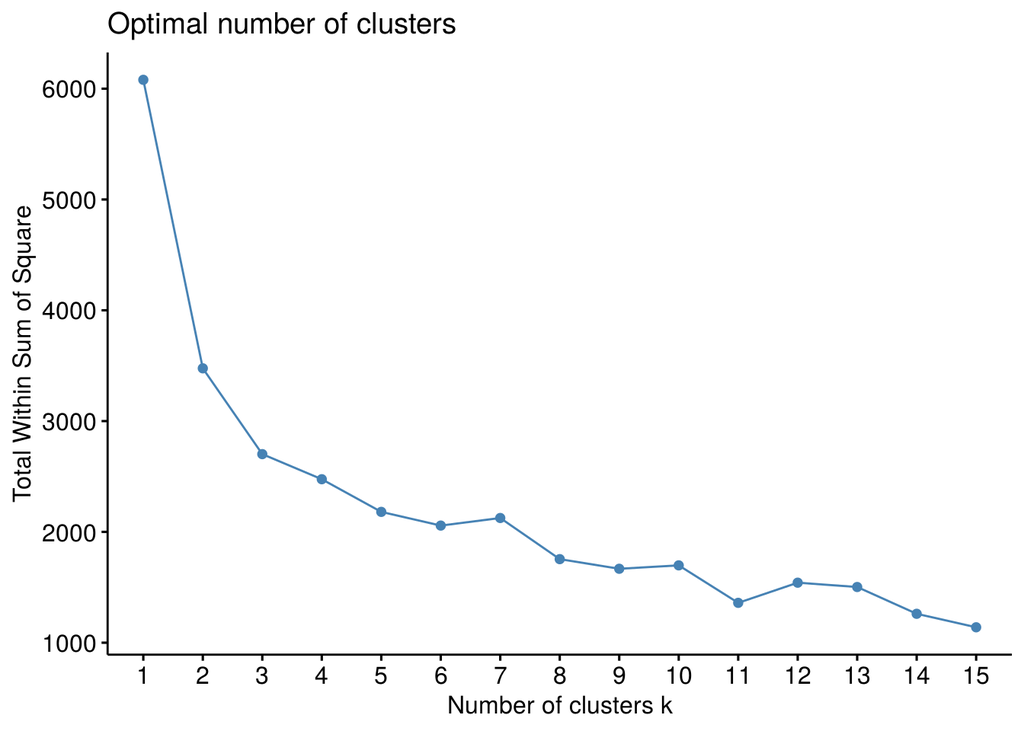

Finalmente, se publica el mapa de Medellín con los respectivos cluster encontrados y se evidencian las conclusiones y los resultados finales del clustering:

[interactive chart not shown]

De esta gráfica se puede concluir varias cosas:

*1.* Otro de los resultados del análisis de clustering es que aquellos barrios con mayor accidentalidad se encuentran ubicados por las zonas valle y mayormente transitadas en la ciudad, calles como la avenida del río, la avenida guayabal, la avenida de la 33 y sus alrededores, y calles como la 30 a la altura de la 80, la 33 con la 65 y la alpujarra entre otros.

*2.* Con base en lo anterior se puede decir también que Medellín es primordial y predominantemente una ciudad céntrica la cual en su mayoría su actividad económica está ubicada en el centro de la ciudad y los alrededores cercanos.

*3.* Así mismo, si se trazará una línea con los puntos rojos se podría observar que esta corresponde en mayor parte a las vías conocidas como **La Regional** y la **Autopista Norte** vías profundamente estratégicas que conectan todo el Valle (sentido Norte-Sur-Norte) lo que por supuesto las hace unas vías con altos índices de movilidad y de manera directa de altos incidentes viales.

*4.* Otra conclusión que se puede derivar de este análisis es que para los corredores viales de la **Avenida la 80** (puntos anaranjados) y la **Autopista Norte** (puntos rojos) es que tienen una infraestructura vial que es limitada para el número de vehículos que la transitan habitualmente, con esto se quiere decir que: la malla vial de de estas zonas es en muchos casos precaria o deficiente, toda vez que hay partes de estas vías en las que se transita en 3 carriles y luego en 2, generando efectos embudo que ante circunstancias cambiantes (lluvia, arreglos viales, represamiento vehicular y demás) son vías más propensas a generar accidentes.

*5.* Finalmente, y como un hecho meramente visual se puede observar que los niveles de accidentalidad **muy alta**, **alta**, **moderada** y **baja** corresponden a cordones, circuitos o capas viales que se van agravando a medida que se acerca al centro de la ciudad.

# Modelado

Como parte entonces del análisis descriptivo y con los resultados obtenidos del proceso de clustering nos adentramos en la parte de modelado. Como fruto del aprendizaje de estas etapas previas se contempla la opción de incluir una sábana de datos que identifique para cada una de las agregaciones de los modelos, los días festivos, los días especiales y los días especiales con festivo esto con ocasión de poder tener un mejor panorama del comportamiento de los accidentes.

Asi mismo, es importante resaltar que el objetivo de la capa de modelamiento se tiene estipulado, predecir el número de accidentes para cada nivel de agregación (Mensual,Semanal y Diario) según la clase de accidente (Choque, Atropello, Caída ocupante, Volcamiento, Otros e Incendios) esto quiere decir que serian para cada nivel de agregación serán 6 modelos esto bajo el entendido que seran modelos de regresion, en total se tendrían 18 modelos. De igual manera, se considera pertinente tener modelos lineales, ya que se cuenta con menos de 50 datos por clase de accidente, por lo que un modelo no-lineal, como árboles de decisión o modelos más avanzados, tenderían a sobre ajustarse fácilmente.

A continuación, se muestra la sábana de datos construida para los días especiales, los festivos y los días especiales con festivos.

## Modelos Mensuales

| PERIODO | MES | DIA | DIA_FESTIVO | FECHA_ESPECIAL | FESTIVO_FECHA_ESPECIAL |
| --- | --- | --- | --- | --- | --- |
| 2014 | 1 | 1 | 1 | 1 | 1 |
| 2014 | 1 | 2 | 0 | 0 | 0 |
| 2014 | 1 | 3 | 0 | 0 | 0 |
| 2014 | 1 | 4 | 0 | 0 | 0 |
| 2014 | 1 | 5 | 0 | 0 | 0 |
| 2014 | 1 | 6 | 1 | 1 | 1 |

Uno de los procesamientos realizados sobre la sábana de datos es el escalamiento de los datos a escala logarítmica para aproximarlos lo más posible a una normal. Así mismo, se construyen nuevas variables como los rezagos del número de accidentes para cada clase de accidentes, esto se da con ocasión del comportamiento de las variables mensuales. Donde se observar las tendencias que tienen los niveles de accidentes según la clase de accidentes.

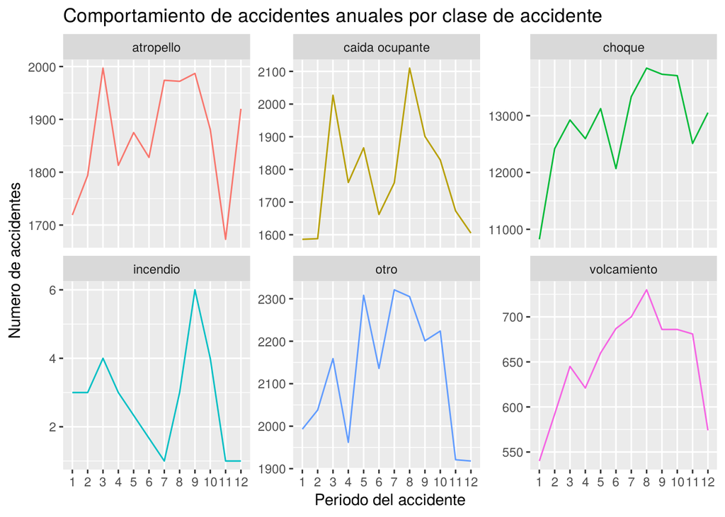

En general para los modelos 5 modelos mensuales la estimación se realiza usando una regresión lineal aplicando **regularización lasso** que es la técnica que presenta menores errores de estimación frente a los modelos entrenados bajo la **stepwise elimination** para seleccionar variables. Para los casos de los modelos con **stepwise elimination** se observaban niveles considerables de sobreajuste al comparar los resultados de entrenamiento y validación. Como se observa en el siguiente gráfico para el modelo de choques:

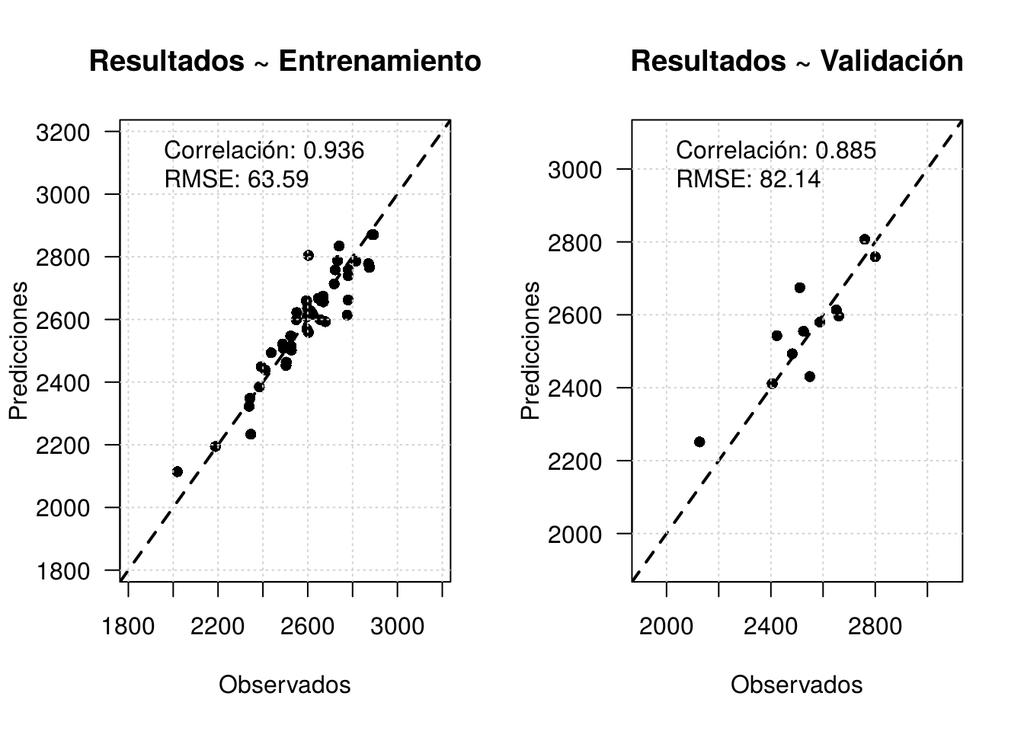

Por último para los modelos mensuales, se grafican los diferentes RMSE tanto de entrenamiento como de validación para las diferentes clases.

De esta tabla se resaltan varias cosas que son importantes mencionar:

*1.* En general se tienen niveles ‘bajos’ para los RMSE esto entendiendo que son pronósticos mensuales y sobretodo para la clase de *choque* en la que se presentan un promedio mensual de más de dos mil incidentes relacionados choques, esto se puede interpretar como un nivel bajo de error de accidentes.

*2.* De la anterior tabla resumen se nota que, la diferencia entre los valores para el RMSE de validación (63) y entrenamiento (31) para la clase *otros* es del doble para validación respecto al entrenamiento; esto sugiere una clara subestimación para esta clase. Una de las razones para esto es que quizás hacen falta más variables que expliquen el comportamiento de este fenómeno puesto que hasta su propia descripción (otros incidentes) pueden ser cualquier otro tipo de factores, lo cual dificulta que se pueda saber con exactitud cuales son las variables que representan de mejor manera este siniestro.

| RMSE_VALIDATION | RMSE_TRAIN | CLASE_MODELO |
| --- | --- | --- |
| 82.14387 | 63.58809 | choque |
| 29.23950 | 24.24131 | atropello |
| 39.39862 | 28.61665 | caida ocupante |
| 21.55456 | 19.89053 | volcamiento |
| 63.28099 | 31.33044 | otro |

## Modelos Semanales

Siguiendo con los modelos semanales se mantiene la misma lógica que en los modelos mensuales: Se utilizan modelos de regresión lineal con penalización lasso y modelos para cada una de las clases. Así mismo, también se extraen los rezagos de los accidentes de la última semana de todas las clases, así como los niveles de gravedad y sus respectivos rezagos.

La siguiente tabla muestra las variables que se tienen en cuenta para el modelo semanal.Esta tabla corresponde también a las variables llevadas a valores logarítmicos, centradas y escaladas.

| SEMANA | atropello | caida ocupante | choque | incendio | otro | volcamiento | herido | muerto | solo danos | t_minus_2 | t_minus_3 | accidentes_domingo | dias_festivos | dias_especiales | dias_festivos_especiales | numero_accidentes |
| --- | --- | --- | --- | --- | --- | --- | --- | --- | --- | --- | --- | --- | --- | --- | --- | --- |
| 4 | 0.4136883 | -0.0585666 | -0.4934288 | 2.9865335 | -0.2323735 | -1.3544516 | -0.7166120 | 1.703705 | -0.1534963 | -1.5103648 | -2.5006412 | -0.4472644 | -0.6081611 | -0.584525 | -0.3888251 | 6.331502 |
| 5 | 1.6054300 | -0.8919562 | -0.2711959 | 2.9865335 | 1.2822620 | -0.7636751 | -0.1688497 | 0.846727 | 0.2127917 | -0.4939650 | -1.4750273 | 0.3895605 | -0.6081611 | -0.584525 | -0.3888251 | 6.297109 |
| 6 | 0.5924496 | 0.0456071 | -0.4722637 | -0.2986534 | 0.7448107 | -2.1421535 | -0.4290368 | 0.418238 | -0.1534963 | -0.2716276 | -0.4703443 | -0.6441644 | -0.6081611 | -0.584525 | -0.3888251 | 6.376727 |
| 7 | 0.6520366 | 0.3060414 | 0.0039495 | -0.2986534 | 0.6959515 | -0.2713614 | -0.1140735 | 0.846727 | 0.5332937 | -0.4727900 | -0.2505699 | 0.0449855 | -0.6081611 | 1.002043 | -0.3888251 | 6.398595 |
| 8 | 0.4732754 | 0.3060414 | 0.1415222 | -0.2986534 | 1.5754173 | -1.0590633 | 0.3789126 | -1.724207 | 0.3806737 | 0.0036474 | -0.4494134 | 0.1434355 | -0.6081611 | -0.584525 | -0.3888251 | 6.354370 |
| 9 | 1.7246041 | 0.4102151 | -0.1336232 | 2.9865335 | 0.5493739 | -1.7483025 | 0.3515245 | 1.275216 | -0.1534963 | 0.1412848 | 0.0215318 | 0.5864605 | -0.6081611 | -0.584525 | -0.3888251 | 6.470800 |

[figure not shown]

[figure not shown]

Para cerrar el análisis de los modelos semanales se presentará una tabla resumen de los RMSE para validación y entrenamiento y se darán las conclusiones generales.

[output not shown]

*1.* Los modelos semanales tuvieron un buen desempeño a nivel general, a excepción de los modelos de **volcamiento** y **otros**, los cuales sufrieron de tener rangos muy cerrados de estimación, por lo que no tienen en cuenta toda la variabilidad total del fenómeno de estudio. Es importante explorar nuevas variables que le permitan a los modelos capturar la variabilidad de estas clases.

## Modelos Diarios

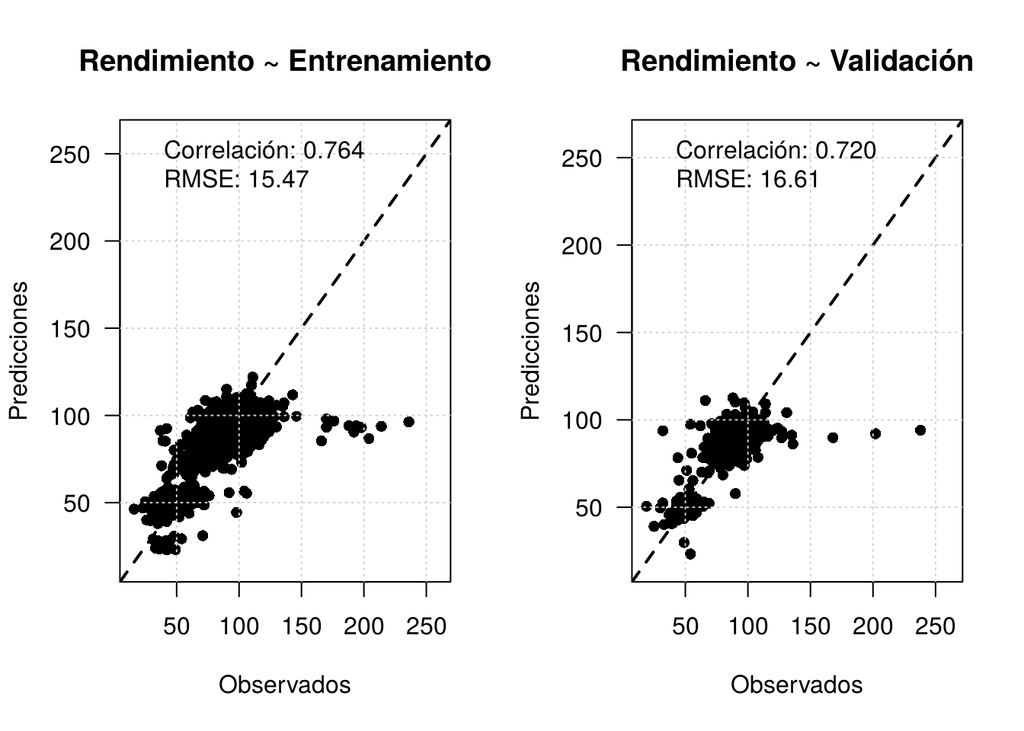

Dado lo anterior se graficaron los errores tanto para validación como para entrenamiento.

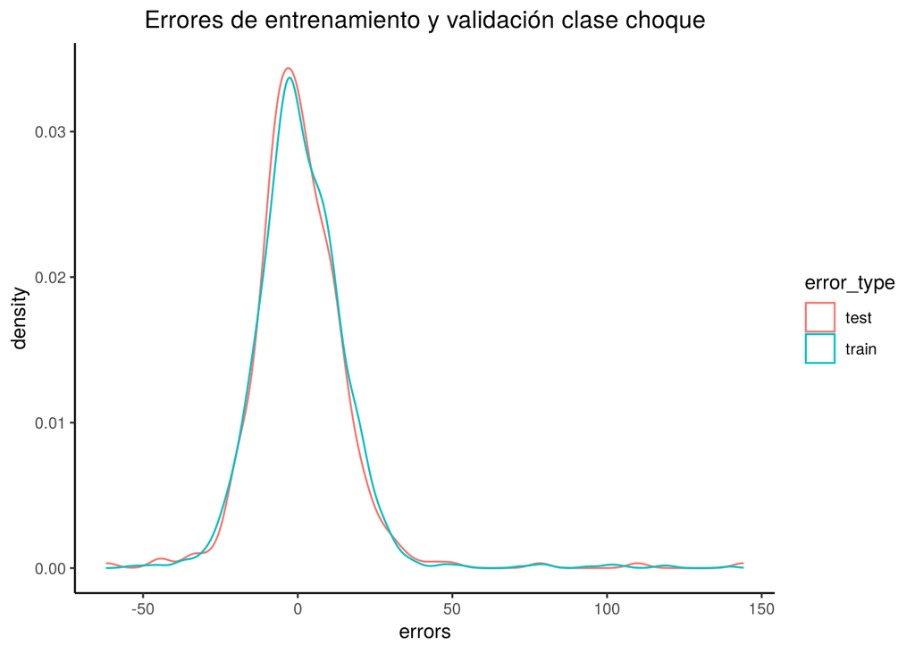

Del análisis de errores, es claro que el modelo tiene problemas de subestimación, ya que las estimaciones no superan los valores de aproximadamente 120 choques por día. Sin embargo, viendo justamente los datos, es una proporción pequeña respecto a todo el conjunto de datos, por lo que podrían denotarse como observaciones más atípicas.

Al continuar con el proceso de entrenamiento de los modelos semanales es preciso decir que si bien para la clase choque la regresión lineal ajusta relativamente bien los datos, para la demás clases esta hipótesis no se cumple a cabalidad. Como se mostrará en el siguiente gráfico para los rmse del modelo de la clase atropello:

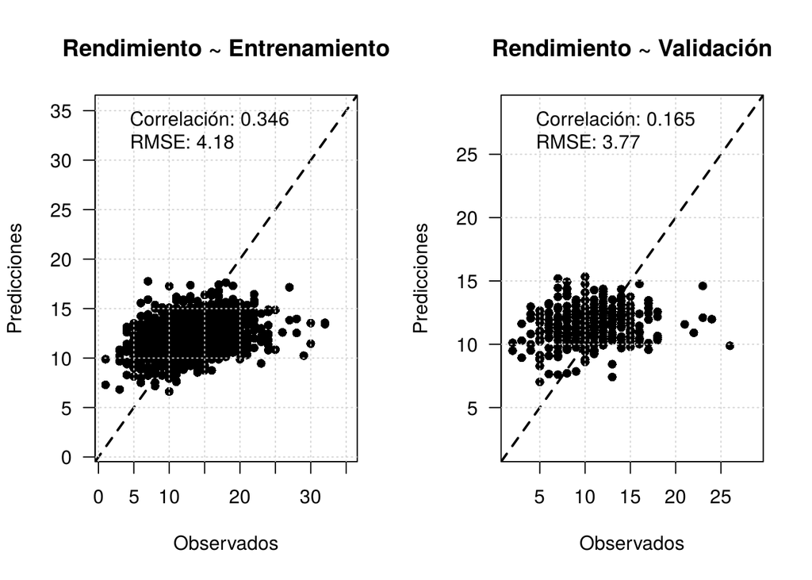

El modelo de regresión lineal claramente parece no ajustarse correctamente a los datos. Sin embargo, en términos de RMSE no se presentan valores exageradamente altos que es lo que sucede cuando no se ajustan los datos a la regresión lineal, esto puede deberse a que hay un comportamiento no lineal atípico y de esta manera se ajusta completamente la regresión lineal.Una de las soluciones puede ser incorporar nuevas variables que logren explicar mejor la variabilidad del fenómeno a estudiar.

[output not shown]

# Conclusiones

En suma, del trabajo en general queda una buena sensacion de los resultados obtenidos, con las oportunidades de mejora correspondientes. Asi mismo, es preciso resaltar que para todo el proyecto se realizo un aplicacion de los conocimientos obtenidos del curso al igual que otros conocimientos previos que hacian enriquecer y refinar los resultados. De igual manera, es importante resaltar el hecho que se haya decidido como entregables el aplicativo web en **Shiny** y los reportes en **Rpubs** pues esto afianza conocimientos y nos invita a realizar publicaciones abiertas al publico y hacer divulgacion de los conocimientos. Otro hecho relevante es la invitacion y la directriz de alojar el proyecto sobre un repositorio lo cual tambien nuevamente genera confianza para la publicacion del conocimiento y poder en algunos casos realizar disscusiones que mejoren los hechos empiricos.

En cuanto a los resultados del trabajo es importante resaltar que:

*1.* Los atropellos se presentan la mayoría de las veces contra ciclistas (ciclo ruta) y contra peatones (vía peatonal) lo cual hace que estos 2 actores (ciclistas y peatones) sean los más vulnerables en las vías.

*2.* Las caídas de ocupante se dan con mayor frecuencia en túneles, lotes o predios y en ciclo rutas.

*5.* Los lugares de la ciudad donde se presentan mayores números de autos también son lugares con mayores niveles de choque: La Candelaria, El poblado, Belén, Guayabal, Robledo y demás, son lugares con alta congestión vehicular lo que puede traducir mayores niveles de choques.

*6.* Para la **clase accidente** se puede realizar una reducción de dimensión, pasando de 6 dimensiones a tan solo 2 dimensiones. Estas nuevas dimensiones (Siniestro con Lesiones -SCL- y Siniestro sin Lesión -SSL-) están relacionadas con si hay o no lesiones en el siniestro. Se observa que para la gravedad solo daños el 99.3% de los siniestros fue sin lecciones lo que hace suponer el la mayoría de la clase de choques son menores y no hay lecciones (materiales graves ni sobre las personas). De esta manera, la clase choque se puede convertir SSL* y las demás clases (atropello, caída ocupante, incendio, otro y volcamiento) se pueden convertir en *SCL*.

*8.* Al trazar una línea con los puntos rojos se podría observar que esta corresponde en mayor parte a las vías conocidas como **La Regional** y la **Autopista Norte** vías profundamente estratégicas que conectan todo el Valle (sentido Norte-Sur-Norte) lo que por supuesto las hace unas vías con altos índices de movilidad y de manera directa de altos incidentes viales.

*9.* Los corredores viales de la **Avenida la 80** (puntos anaranjados) y la **Autopista Norte** (puntos rojos) es que tienen una infraestructura vial que es limitada para el número de vehículos que la transitan habitualmente, con esto se quiere decir que: la malla vial de de estas zonas es en muchos casos precaria o deficiente, toda vez que hay partes de estas vías en las que se transita en 3 carriles y luego en 2, generando efectos embudo que ante circunstancias cambiantes (lluvia, arreglos viales, represamiento vehicular y demás) son vías más propensas a generar accidentes.

*11.* En general para los modelos 5 modelos mensuales la estimación se realiza usando una regresión lineal aplicando **regularización lasso** que es la técnica que presenta menores errores de estimación frente a los modelos entrenados bajo la **stepwise elimination** para seleccionar variables. Para los casos de los modelos con **stepwise elimination** se observaban niveles considerables de sobreajuste al comparar los resultados de entrenamiento y validación.

*13.* Los modelos para las clases **volcamiento** y **otros** se consideran para los 3 niveles de agregación una oportunidad de mejora. Ya que estos sufrieron de tener rangos muy cerrados de estimación, por lo que no tienen en cuenta toda la variabilidad total del fenómeno de estudio. Es importante explorar nuevas variables que le permitan a los modelos capturar la variabilidad de estas clases. Adicional a esto, son eventos que desde su concepción pueden limitar el análisis: pues son incidentes viales (muy graves por supuesto) con baja frecuencia de accidentes, esto no quiere decir que esté mal, sino por el contrario es positivo. Sin embargo, pero para el objeto que nos compete (realizar modelos predictivos) no son de mucha ayuda el tener pocas observaciones o hace que se deban tratar con otras metodologías (detección de anomalías).

# Enlaces de resultados

**El repositorio del proyecto se encuentra en el siguiente enlace**

- [Github](https://github.com/alcadavidro/medellin-movility-analytics)

**El reporte del analisis exploratorio de los datos se encuentra en el siguiente enlace**

- [Exploratory Descriptive Analysis](https://rpubs.com/santy1129/654267)

**Los Reportes de los modelos predictivos se encuentran en los siguiente enlace**

- [Daily models](https://rpubs.com/Alejocadro/655645)
- [Weekly models](https://rpubs.com/santy1129/655996)
- [Monthly models](https://rpubs.com/santy1129/655997)

**El reporte de la clusterizacion se encuentra en el siguiente enlace**

- [Clustering analysis](https://rpubs.com/santy1129/656000)

**El video promocional de la pagina web se encuentra en el siguiente enlace**

- [Web App](https://alejocad03.shinyapps.io/accidentalidad_medellin/)

**El video promocional de la pagina web se encuentra en el siguiente enlace**

- [Promotional Video](https://www.youtube.com/watch?v=A7xWfvU76ZI&rel=0&utm_source=broadcast&utm_medium=email&utm_campaign=Transactional-Publish-success)